# impacto del agua y el tabaquismo en el cancer de colon

Fuentes de datos Biomédicas y Web semántica, Grado de Ingeniería de la Salud

Álvaro Martín,Miguel Soriano, Andres Arribas

2024-12-02

# **Introducción**

El cáncer de colon es una de las enfermedades oncológicas más comunes, la cual ocasiona incontables perdidas cada año en todo el mundo. A lo largo de este proyecto, tratamos distintas bases de datos donde se estudia su prevalencia, su impacto y como se relaciona con dos importantes factores que afectan a la salud: el tabaquismo y la calidad del agua.

Por un lado, el tabaquismo, es ampliamente estudiado como factor de riesgo para diferentes tipos de cáncer; afectando tambien al colon dado que las sustancias químicas del tabaco dañan las células intestinales promoviendo su crecimiento anormal.

Por otro lado, la calidad del agua también es crucial en la salud gastrointestinal ya que su exposición a químicos nocivos puede afectar negativamente a la salud digestiva.

Hemos elegido centrarnos solo en la region de Asturias en España dados los datos encontrados, los cuales hemos usado para explorar esta posible relacion entre estos dos factores y el cancer de colon.

## **Objetivos**

El propósito principal de este estudio es explorar y entender la relación entre el tabaquismo, la calidad del agua, y la incidencia del cáncer de colon en la region de asturias. Para lograr esto, hemos establecido los siguientes objetivos específicos:

1. **Analizar la prevalencia del tabaquismo**: Estudiar la prevalencia del tabaquismo en la region de asturias y su correlación con la incidencia del cáncer de colon.
2. **Evaluar la calidad del agua**: Investigar la calidad del agua en la region de asturias y su posible relación con la incidencia del cáncer de colon.
3. **Investigar la incidencia del cáncer de colon**: Analizar la incidencia del cáncer en la region de asturias y su posible correlación con el tabaquismo y la calidad del agua.
4. **Explorar la interacción entre estos factores**: Investigar cómo el tabaquismo y la calidad del agua pueden interactuar entre sí y su impacto conjunto en la incidencia del cáncer de colon basandonos en los datos hallados de la region de asturias.

A través de estos objetivos, esperamos proporcionar una visión más completa de cómo estos factores pueden influir en la salud humana y contribuir al conocimiento de la incidencia del cáncer de colon.

# Importación de algunos paquetes y librerias necesarios

En este apartado añadimos todas las librerias y paquetes necesarios para realizar el trabajo

```r
library(tidyverse)
library(readxl)
library(readr)
library(jsonlite)
library(dplyr)
library(tidyr)
library(purrr)
library(stringr)
library(reshape2)
```

# Importacion de las fuentes de datos

En este apartado añadimos las diferentes fuentes de datos que hemos utilizado para el estudio directamente utilizando los formatos csv y JSON para poder manipular los datos

```r
#carga de datos csv sobre calidad de agua en gijon
Agua_gijon <- read_delim("INPUT/DATA/731.csv",
                      delim = ",", escape_double = FALSE, trim_ws = TRUE)
Agua_gijon
```

```
## # A tibble: 72 × 30
##       Id   Año Mes       `Punto de Muestreo`  Color Max: 15 Ud: pl…¹  Olor Sabor
##    <dbl> <dbl> <chr>     <chr>                <chr>                  <dbl> <dbl>
##  1    80  2024 Julio     Salida de los depós… 2                          1     1
##  2    79  2024 Junio     Salida de los depós… 0                          1     1
##  3    78  2024 Mayo      Salida de los depós… 1                          1     1
##  4    77  2024 Abril     Salida de los depós… 1                          1     1
##  5    76  2024 Marzo     Salida de los depós… 4                          1     1
##  6    75  2024 Febrero   Salida de los depós… 2                          1     1
##  7    74  2024 Enero     Salida de los depós… 3                          1     1
##  8    73  2023 Diciembre Salida de los depós… 8                          1     1
##  9    72  2023 Noviembre Salida de los depós… 7                          1     1
## 10    71  2023 octubre   Salida de los depós… 2                          1     1
## # ℹ 62 more rows
## # ℹ abbreviated name: ¹`Color Max: 15 Ud: pl/mg`
## # ℹ 23 more variables: `Cloro Libre` <chr>, Turbidez <chr>, pH <dbl>,
## #   Conductividad <dbl>, Temperatura <dbl>, Dureza <dbl>, Nitratos <dbl>,
## #   Nitritos <chr>, Amonio <chr>, Cloruros <dbl>, Fluor <chr>, Sodio <dbl>,
## #   Aluminio <chr>, Trihalometanos <chr>, Oxidabilidad <chr>,
## #   `Bacterías Coliformes` <dbl>, Enterococos <dbl>, …
```

```r
summary(Agua_gijon)
```

```
##        Id             Año           Mes            Punto de Muestreo
##  Min.   : 2.00   Min.   :2018   Length:72          Length:72
##  1st Qu.:23.75   1st Qu.:2019   Class :character   Class :character
##  Median :42.50   Median :2021   Mode  :character   Mode  :character
##  Mean   :42.46   Mean   :2021
##  3rd Qu.:62.25   3rd Qu.:2023
##  Max.   :80.00   Max.   :2024
##
##  Color Max: 15 Ud: pl/mg      Olor       Sabor   Cloro Libre
##  Length:72               Min.   :1   Min.   :1   Length:72
##  Class :character        1st Qu.:1   1st Qu.:1   Class :character
##  Mode  :character        Median :1   Median :1   Mode  :character
##                          Mean   :1   Mean   :1
##                          3rd Qu.:1   3rd Qu.:1
##                          Max.   :1   Max.   :1
##
##    Turbidez               pH         Conductividad    Temperatura
##  Length:72          Min.   :     8   Min.   :175.0   Min.   :  9.6
##  Class :character   1st Qu.:    77   1st Qu.:200.0   1st Qu.:103.0
##  Mode  :character   Median :    78   Median :211.0   Median :118.0
##                     Mean   :  6434   Mean   :209.4   Mean   :118.1
##                     3rd Qu.:    79   3rd Qu.:220.0   3rd Qu.:138.0
##                     Max.   :451450   Max.   :233.0   Max.   :193.0
##                     NA's   :1        NA's   :1       NA's   :1
##      Dureza         Nitratos       Nitritos            Amonio
##  Min.   : 92.0   Min.   : 3.00   Length:72          Length:72
##  1st Qu.:107.0   1st Qu.:19.00   Class :character   Class :character
##  Median :114.0   Median :22.00   Mode  :character   Mode  :character
##  Mean   :114.6   Mean   :23.15
##  3rd Qu.:119.5   3rd Qu.:26.00
##  Max.   :150.0   Max.   :68.00
##  NA's   :1       NA's   :4
##     Cloruros        Fluor               Sodio         Aluminio
##  Min.   : 6.00   Length:72          Min.   : 3.00   Length:72
##  1st Qu.:48.00   Class :character   1st Qu.:28.00   Class :character
##  Median :52.00   Mode  :character   Median :31.00   Mode  :character
##  Mean   :54.75                      Mean   :30.49
##  3rd Qu.:57.00                      3rd Qu.:32.00
##  Max.   :91.00                      Max.   :97.00
##  NA's   :3                          NA's   :3
```

[output cut: 9 more lines]

```
##  Min.   : 0.000          Min.   :0        Min.   :0
##  1st Qu.: 0.000          1st Qu.:0        1st Qu.:0
##  Median : 1.000          Median :0        Median :0
##  Mean   : 1.451          Mean   :0        Mean   :0
##  3rd Qu.: 2.000          3rd Qu.:0        3rd Qu.:0
##  Max.   :10.000          Max.   :0        Max.   :0
##  NA's   :1               NA's   :1        NA's   :1
##  Pseudomonas aeruginosa     Calcio         Magnesio
##  Min.   :0              Min.   :312.0   Min.   : 3.50
##  1st Qu.:0              1st Qu.:353.0   1st Qu.:45.00
##  Median :0              Median :381.0   Median :46.00
##  Mean   :0              Mean   :382.9   Mean   :45.26
##  3rd Qu.:0              3rd Qu.:406.0   3rd Qu.:51.00
##  Max.   :0              Max.   :457.0   Max.   :57.00
##  NA's   :5              NA's   :23      NA's   :23
```

```r
table(Agua_gijon$T.RED)
```

```
## < table of extent 0 >
```

```r
#carga de datos json sobre los fumadores en asturias incluyendo a gijon
library(tidyverse)
library(jsonlite)

datos_fumadores <- fromJSON("INPUT/DATA/Fumadores.json", flatten = TRUE) %>%
  as_tibble()
datos_fumadores <- datos_fumadores %>%
  separate(Nombre, into = c("Sexo", "Region", "Categoria"), sep = ", ", fill = "right")
# Visualizar los datos para confirmar la estructura
#summary(datos_fumadores)

#carga de cancer de colon
library(readxl)
datosEnfermedades <- read_excel("INPUT/DATA/03009d.xlsx", skip = 5)
# Visualizar la tabla general
#summary(datosEnfermedades)
```

# Cambios en las fuentes de datos

Este paso es necesario ya que al relacionar todas las tablas entre si necesitamos que aquellas columnas que son comunes tengan los mismos nombres, por ello se ha requerido que todos los nombres de las comunidades y ciudades autonomas presentes sean cambiados a nombres comunes elegidos por el grupo. Por otro lado hemos usado el select para seleccionar las columnas de datos que nos resultan de interes para el estudio.

```r
# Cargar librerías necesarias
library(tidyverse)
library(jsonlite)
# Cargar el archivo JSON de fumadores
datos_fumadores <- fromJSON("INPUT/DATA/Fumadores.json", flatten = TRUE) %>%
  as_tibble()
fumadores_asturias <- datos_fumadores %>%
  separate(Nombre, into = c("Sexo", "Region", "Categoria"), sep = ", ", fill = "right") %>%
  filter(Region == "Asturias (Principado de)")
fumadores_asturias_expandido <- fumadores_asturias %>%
  mutate(
    Variable_Nombre = map(MetaData, ~ .x[["Variable.Nombre"]][1]),
    Variable_Codigo = map(MetaData, ~ .x[["Variable.Codigo"]][1]),
    Valor = map(Data, ~ .x[["Valor"]][1])
  ) %>%
  unnest(c(Variable_Nombre, Variable_Codigo, Valor))
fumadores_asturias_final <- fumadores_asturias_expandido %>%
  select(Sexo, Region, Categoria, Variable_Nombre, Variable_Codigo, Valor)
#View(fumadores_asturias_final)
summary(fumadores_asturias_final)
```

```
##      Sexo              Region           Categoria         Variable_Nombre
##  Length:15          Length:15          Length:15          Length:15
##  Class :character   Class :character   Class :character   Class :character
##  Mode  :character   Mode  :character   Mode  :character   Mode  :character
##
##
##
##  Variable_Codigo        Valor
##  Length:15          Min.   :  1.51
##  Class :character   1st Qu.: 17.83
##  Mode  :character   Median : 31.30
##                     Mean   : 40.00
##                     3rd Qu.: 52.70
##                     Max.   :100.00
```

```r
#carga de datos xlsx sobre algunas enfermedades en asturias, entre ellas el cancer de colon
datosEnfermedades <-  read_excel("INPUT/DATA/03009d.xlsx")
str(datosEnfermedades)
```

```
## tibble [1,545 × 7] (S3: tbl_df/tbl/data.frame)
##  $ ...1   : chr [1:1545] "TOTAL ENFERMEDADES" "Total" "Hombres" "Mujeres" ...
##  $ Total  : chr [1:1545] NA "231014" "115541" "115473" ...
##  $ ENERO  : chr [1:1545] NA "34395" "17044" "17351" ...
##  $ FEBRERO: chr [1:1545] NA "60304" "28860" "31444" ...
##  $ MARZO  : chr [1:1545] NA "57531" "30219" "27312" ...
##  $ ABRIL  : chr [1:1545] NA "36103" "18101" "18002" ...
##  $ MAYO   : chr [1:1545] NA "42681" "21317" "21364" ...
```

```r
summary(datosEnfermedades)
```

```
##      ...1              Total              ENERO             FEBRERO
##  Length:1545        Length:1545        Length:1545        Length:1545
##  Class :character   Class :character   Class :character   Class :character
##  Mode  :character   Mode  :character   Mode  :character   Mode  :character
##     MARZO              ABRIL               MAYO
##  Length:1545        Length:1545        Length:1545
##  Class :character   Class :character   Class :character
##  Mode  :character   Mode  :character   Mode  :character
```

```r
#View(datosEnfermedades)
```

# Pregunta 1

## ¿cual es la incidencia del tabaquismo en asturias?¿Hay relacion con el cancer de colon? En caso de haberla, ¿Como afecta dicha relacion?

Tratamiento de datos de los fumadores:

```r
#Extraer solo los campos necesarios del JSON
fumadores_asturias <- datos_fumadores %>%
  mutate(
    Valor = map_dbl(Data, ~ if (!is.null(.x$Valor)) .x$Valor else NA_real_)
  ) %>%
  select(Nombre, Valor) %>%
  filter(grepl("Asturias", Nombre))
print(fumadores_asturias)
```

```
## # A tibble: 15 × 2
##    Nombre                                                    Valor
##    <chr>                                                     <dbl>
##  1 Ambos sexos, Asturias (Principado de), TOTAL             100
##  2 Ambos sexos, Asturias (Principado de), Fumador diario     19.2
##  3 Ambos sexos, Asturias (Principado de), Fumador ocasional   1.93
##  4 Ambos sexos, Asturias (Principado de), Ex fumador         31.3
##  5 Ambos sexos, Asturias (Principado de), Nunca ha fumado    47.5
##  6 Hombres, Asturias (Principado de), TOTAL                 100
##  7 Hombres, Asturias (Principado de), Fumador diario         22.4
##  8 Hombres, Asturias (Principado de), Fumador ocasional       2.39
##  9 Hombres, Asturias (Principado de), Ex fumador             39.1
## 10 Hombres, Asturias (Principado de), Nunca ha fumado        36.1
## 11 Mujeres, Asturias (Principado de), TOTAL                 100
## 12 Mujeres, Asturias (Principado de), Fumador diario         16.4
## 13 Mujeres, Asturias (Principado de), Fumador ocasional       1.51
## 14 Mujeres, Asturias (Principado de), Ex fumador             24.2
## 15 Mujeres, Asturias (Principado de), Nunca ha fumado        57.9
```

```r
fumadores_relevantes <- fumadores_asturias %>%
  filter(
    grepl("Fumador diario|Fumador ocasional|Ex fumador|Nunca ha fumado", Nombre)
  )
print(fumadores_relevantes)
```

```
## # A tibble: 12 × 2
##    Nombre                                                   Valor
##    <chr>                                                    <dbl>
##  1 Ambos sexos, Asturias (Principado de), Fumador diario    19.2
##  2 Ambos sexos, Asturias (Principado de), Fumador ocasional  1.93
##  3 Ambos sexos, Asturias (Principado de), Ex fumador        31.3
##  4 Ambos sexos, Asturias (Principado de), Nunca ha fumado   47.5
##  5 Hombres, Asturias (Principado de), Fumador diario        22.4
##  6 Hombres, Asturias (Principado de), Fumador ocasional      2.39
##  7 Hombres, Asturias (Principado de), Ex fumador            39.1
##  8 Hombres, Asturias (Principado de), Nunca ha fumado       36.1
##  9 Mujeres, Asturias (Principado de), Fumador diario        16.4
## 10 Mujeres, Asturias (Principado de), Fumador ocasional      1.51
## 11 Mujeres, Asturias (Principado de), Ex fumador            24.2
## 12 Mujeres, Asturias (Principado de), Nunca ha fumado       57.9
```

Tratamiento de datos del cancer de colon:

```r
datosEnfermedades <- read_excel("INPUT/DATA/03009d.xlsx")
cancer_colon_final <- datosEnfermedades %>%
  filter(grepl("Cáncer de colon|Total|Hombres|Mujeres", `...1`)) %>%
  select(`...1`, Total, ENERO, FEBRERO, MARZO, ABRIL, MAYO) %>%
  rename(
    Categoria = `...1`
  ) %>%
  filter(row_number() %in% (which(grepl("Cáncer de colon", Categoria))[1]:(which(grepl("Cáncer de colon", Categoria))[1] + 3))) %>%
  mutate(across(Total:MAYO, as.numeric))
print(cancer_colon_final)
```

```
## # A tibble: 4 × 7
##   Categoria       Total ENERO FEBRERO MARZO ABRIL  MAYO
##   <chr>           <dbl> <dbl>   <dbl> <dbl> <dbl> <dbl>
## 1 Cáncer de colon    NA    NA      NA    NA    NA    NA
## 2 Total            4579   867     837   979   928   968
## 3 Hombres          2628   515     476   531   536   570
## 4 Mujeres          1951   352     361   448   392   398
```

Desarrollo de la relacion entre ambos conceptos:

```r
# Procesar los datos de tabaquismo
fumadores_asturias <- fumadores_asturias %>%
  filter(grepl("Fumador diario|Fumador ocasional|Ex fumador|Nunca ha fumado", Nombre)) %>%
  mutate(Grupo = case_when(
    grepl("Hombres", Nombre) ~ "Hombres",
    grepl("Mujeres", Nombre) ~ "Mujeres",
    grepl("Ambos sexos", Nombre) ~ "Total",
    TRUE ~ NA_character_
  )) %>%
  select(Grupo, Nombre, Valor)
tabla_combinada <- fumadores_asturias %>%
  filter(Grupo %in% c("Total", "Hombres", "Mujeres")) %>%  # Filtrar grupos relevantes
  left_join(cancer_colon_final %>% select(Categoria, Total), by = c("Grupo" = "Categoria")) %>%
  rename(
    PrevalenciaTabaquismo = Valor,
    CasosCancerColonTotal = Total
  ) %>%
  mutate(
    CasosCancerColonPonderados = (PrevalenciaTabaquismo / 100) * CasosCancerColonTotal  # Ponderar casos de cáncer
  )
print(tabla_combinada)
```

```
## # A tibble: 12 × 5
##    Grupo   Nombre                    PrevalenciaTabaquismo CasosCancerColonTotal
##    <chr>   <chr>                                     <dbl>                 <dbl>
##  1 Total   Ambos sexos, Asturias (P…                 19.2                   4579
##  2 Total   Ambos sexos, Asturias (P…                  1.93                  4579
##  3 Total   Ambos sexos, Asturias (P…                 31.3                   4579
##  4 Total   Ambos sexos, Asturias (P…                 47.5                   4579
##  5 Hombres Hombres, Asturias (Princ…                 22.4                   2628
##  6 Hombres Hombres, Asturias (Princ…                  2.39                  2628
##  7 Hombres Hombres, Asturias (Princ…                 39.1                   2628
##  8 Hombres Hombres, Asturias (Princ…                 36.1                   2628
##  9 Mujeres Mujeres, Asturias (Princ…                 16.4                   1951
## 10 Mujeres Mujeres, Asturias (Princ…                  1.51                  1951
## 11 Mujeres Mujeres, Asturias (Princ…                 24.2                   1951
## 12 Mujeres Mujeres, Asturias (Princ…                 57.9                   1951
## # ℹ 1 more variable: CasosCancerColonPonderados <dbl>
```

```r
# Análisis de correlación entre tabaquismo (fumadores diarios) y cáncer de colon
correlacion <- tabla_combinada %>%
  filter(grepl("Fumador diario", Nombre)) %>%
  summarise(Correlacion = cor(PrevalenciaTabaquismo, CasosCancerColonTotal, use = "complete.obs"))
print(correlacion)
```

```
## # A tibble: 1 × 1
##   Correlacion
##         <dbl>
## 1       0.221
```

Grafico demostrativo:

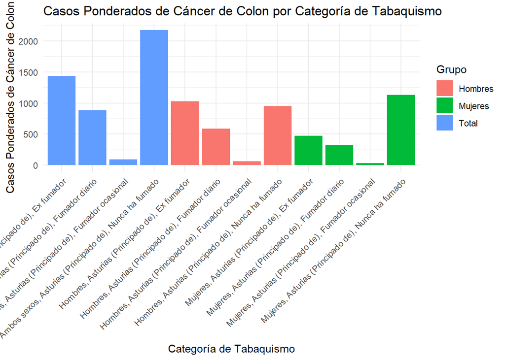

```r
# Crear un gráfico de dispersión para visualizar la relación
library(ggplot2)
tabla_combinada %>%
  ggplot(aes(x = Nombre, y = CasosCancerColonPonderados, fill = Grupo)) +
  geom_bar(stat = "identity", position = "dodge") +
  labs(
    title = "Casos Ponderados de Cáncer de Colon por Categoría de Tabaquismo",
    x = "Categoría de Tabaquismo",
    y = "Casos Ponderados de Cáncer de Colon"
  ) +
  theme_minimal() +
  theme(axis.text.x = element_text(angle = 45, hjust = 1))
```

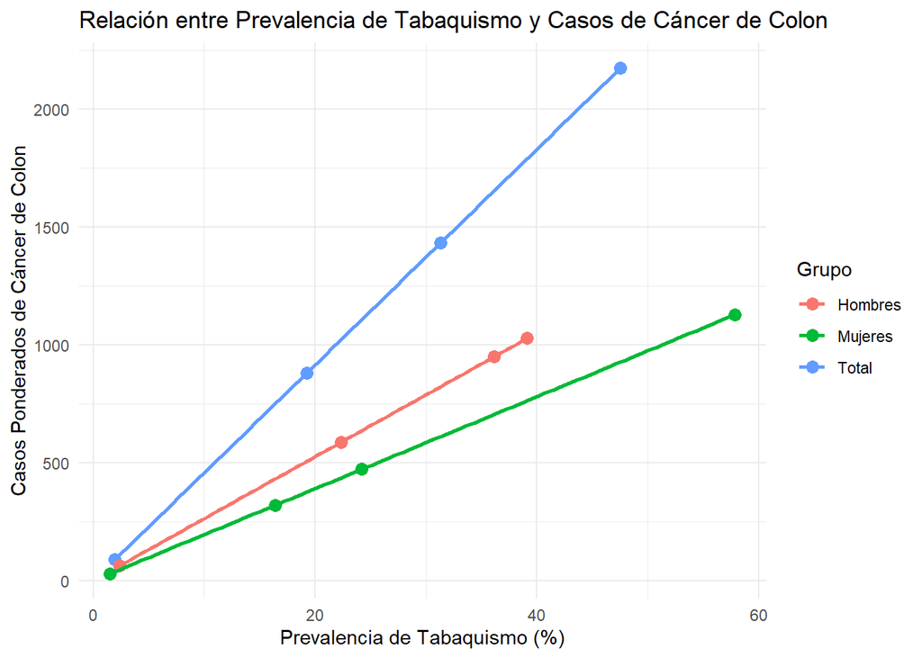

```r
tabla_combinada %>%
  ggplot(aes(x = PrevalenciaTabaquismo, y = CasosCancerColonPonderados, color = Grupo)) +
  geom_point(size = 3) +
  geom_smooth(method = "lm", se = FALSE) +
  labs(
    title = "Relación entre Prevalencia de Tabaquismo y Casos de Cáncer de Colon",
    x = "Prevalencia de Tabaquismo (%)",
    y = "Casos Ponderados de Cáncer de Colon"
  ) +
  theme_minimal()
```

# Conclusion

Los gráficos muestran una relación positiva entre la prevalencia de tabaquismo y los casos ponderados de cáncer de colon, siendo más marcada en hombres. Sin embargo, el mayor número de casos en el grupo “Nunca ha fumado” sugiere que otros factores, como predisposición genética o ambientales, podrían influir.

# Pregunta 2

## A nivel de calidad del agua de Gijon, ¿Que tan bueno es el tratamiento que se le realiza al agua para que sea potable y ademas lo mas pura y limpia posible?¿Se considera que tiene buen nivel de salubridad?¿Hay relacion con el cancer de colon? En caso de haberla, ¿Como afecta dicha relacion?

Tratamiento de datos del agua:

```r
library(readr)
library(dplyr)
library(tidyr)

Agua_gijon_ej2 <- read_delim("INPUT/DATA/123.csv",
                             delim = ";",
                             locale = locale(decimal_mark = ","),
                             escape_double = FALSE,
                             trim_ws = TRUE,
                             show_col_types = FALSE)
Agua_gijon_ej2 <- Agua_gijon_ej2 %>%
  mutate(Mes = toupper(Mes))
datos_2020 <- Agua_gijon_ej2 %>%
  filter(Año == 2020, Mes %in% c("ENERO", "FEBRERO", "MARZO", "ABRIL", "MAYO"))
datos_2020 <- datos_2020 %>%
  mutate(
    Mes = factor(Mes, levels = c("ENERO", "FEBRERO", "MARZO", "ABRIL", "MAYO"))
  ) %>%
  arrange(Mes)

# Clasificación de la calidad para todos los parámetros del agua la mayoria segun la OMS
calidad_componentes <- datos_2020 %>%
  mutate(
    Calidad_pH = case_when(
      pH >= 6.5 & pH <= 8.5 ~ "Recomendable",
      pH < 6.5 ~ "Ácida",
      pH > 8.5 ~ "Alcalina",
      TRUE ~ "Desconocida"
    ),
    Calidad_Turbidez = case_when(
      Turbidez <= 1 ~ "Recomendable",
      Turbidez > 1 & Turbidez <= 5 ~ "Aceptable",
      Turbidez > 5 ~ "Mala",
      TRUE ~ "Desconocida"
    ),
    Calidad_Cloro = case_when(
      `Cloro Libre` <= 0.5 ~ "Recomendable",
      `Cloro Libre` > 0.5 & `Cloro Libre` <= 1.5 ~ "Moderada",
      `Cloro Libre` > 1.5 & `Cloro Libre` <= 4.0 ~ "Alta",
      `Cloro Libre` > 4.0 ~ "Excesiva",
      TRUE ~ "Desconocida"
    ),
    Calidad_Color = case_when(
      as.numeric(`Color Max: 15 Ud: pl/mg`) <= 15 ~ "Recomendable",
      as.numeric(`Color Max: 15 Ud: pl/mg`) > 15 ~ "No Aceptable",
      TRUE ~ "Desconocida"
    ),
    Calidad_Olor = case_when(
      Olor == 0 ~ "No aceptable",
      Olor > 0 ~ "Recomendable",
      TRUE ~ "Desconocida"
    ),
    Calidad_Sabor = case_when(
      Sabor == 0 ~ "No recomendable",
      Sabor > 0 ~ "Recomendable",
      TRUE ~ "Desconocida"
    ),
    Calidad_Temperatura = case_when(
      Temperatura <= 25 ~ "Recomendable",
      Temperatura > 25 ~ "No Aceptable",
      TRUE ~ "Desconocida"
    ),
    Calidad_Cloruros = case_when(
      Cloruros <= 250 ~ "Recomendable",
      Cloruros > 250 ~ "Alta",
      TRUE ~ "Desconocida"
    ),
    Calidad_Fluor = case_when(
      Fluor <= 1.5 ~ "Recomendable",
      Fluor > 1.5 ~ "No Aceptable",
      TRUE ~ "Desconocida"
    ),
    Calidad_Sodio = case_when(
      Sodio <= 200 ~ "Recomendable",
      Sodio > 200 ~ "Alta",
      TRUE ~ "Desconocida"
    ),
    Calidad_Aluminio = case_when(
      Aluminio <= 0.2 ~ "Recomendable",
      Aluminio > 0.2 ~ "Alta",
      TRUE ~ "Desconocida"
    ),
    Calidad_Trihalometanos = case_when(
      Trihalometanos <= 100 ~ "Recomendable",
      Trihalometanos > 100 ~ "Alta",
      TRUE ~ "Desconocida"
    ),
    Calidad_Oxidabilidad = case_when(
      Oxidabilidad <= 5 ~ "Recomendable",
      Oxidabilidad > 5 ~ "Alta",
      TRUE ~ "Desconocida"
    ),
    Calidad_Germenes22C = case_when(
      `Gérmenes Totales a 22ºC` <= 100 ~ "Recomendable",
      `Gérmenes Totales a 22ºC` > 100 ~ "Alta",
      TRUE ~ "Desconocida"
    ),
    Calidad_Clostridium = case_when(
      `Clostridium perfringens` == 0 ~ "Recomendable",
      `Clostridium perfringens` > 0 ~ "No Aceptable",
      TRUE ~ "Desconocida"
    ),
    Calidad_Calcio = case_when(
      Calcio <= 100 ~ "Bajo",
      Calcio > 100 & Calcio <= 300 ~ "Moderado",
      Calcio > 300 ~ "Alto",
      TRUE ~ "Desconocida"
    ),
    Calidad_Magnesio = case_when(
      Magnesio <= 30 ~ "Bajo",
      Magnesio > 30 & Magnesio <= 50 ~ "Moderado",
      Magnesio > 50 ~ "Alto",
      TRUE ~ "Desconocida"
    )
  )

#resumen de calidad por mes con columna final para el analisis
resumen_por_mes <- calidad_componentes%>%
  group_by(Mes) %>%
  summarise(
    Calidad_pH = case_when(
      Calidad_pH == "Recomendable" ~ "Recomendable",
      Calidad_pH == "Ácida" ~ "Ácida",
      Calidad_pH == "Alcalina" ~ "Alcalina",
      TRUE ~ "Desconocida"
    ),
    Calidad_Turbidez = case_when(
      Calidad_Turbidez == "Recomendable" ~ "Recomendable",
      Calidad_Turbidez == "Aceptable" ~ "Aceptable",
      Calidad_Turbidez == "Mala" ~ "Mala",
      TRUE ~ "Desconocida"
    ),
    Calidad_Cloro = case_when(
      Calidad_Cloro == "Recomendable" ~ "Recomendable",
      Calidad_Cloro == "Moderada" ~ "Moderada",
      Calidad_Cloro == "Alta" ~ "Alta",
      Calidad_Cloro == "Excesiva" ~ "Excesiva",
      TRUE ~ "Desconocida"
    ),
    Calidad_Color = case_when(
      Calidad_Color == "Recomendable" ~ "Recomendable",
      Calidad_Color == "No Aceptable" ~ "No Aceptable",
      TRUE ~ "Desconocida"
    ),
    Calidad_Olor = case_when(
      Calidad_Olor == "No aceptable" ~ "No aceptable",
      Calidad_Olor == "Recomendable" ~ "Recomendable",
      TRUE ~ "Desconocida"
    ),
    Calidad_Sabor = case_when(
      Calidad_Sabor == "No recomendable" ~ "No recomendable",
      Calidad_Sabor == "Recomendable" ~ "Recomendable",
      TRUE ~ "Desconocida"
    ),
    Calidad_Temperatura = case_when(
      Calidad_Temperatura == "Recomendable" ~ "Recomendable",
      Calidad_Temperatura == "No Aceptable" ~ "No Aceptable",
      TRUE ~ "Desconocida"
    ),
    Calidad_Cloruros = case_when(
      Calidad_Cloruros == "Recomendable" ~ "Recomendable",
      Calidad_Cloruros == "Alta" ~ "Alta",
      TRUE ~ "Desconocida"
    ),
    Calidad_Fluor = case_when(
      Calidad_Fluor == "Recomendable" ~ "Recomendable",
      Calidad_Fluor == "No Aceptable" ~ "No Aceptable",
      TRUE ~ "Desconocida"
    ),
    Calidad_Sodio = case_when(
      Calidad_Sodio == "Recomendable" ~ "Recomendable",
      Calidad_Sodio == "Alta" ~ "Alta",
      TRUE ~ "Desconocida"
    ),
    Calidad_Aluminio = case_when(
      Calidad_Aluminio == "Recomendable" ~ "Recomendable",
      Calidad_Aluminio == "Alta" ~ "Alta",
      TRUE ~ "Desconocida"
    ),
    Calidad_Trihalometanos = case_when(
      Calidad_Trihalometanos == "Recomendable" ~ "Recomendable",
      Calidad_Trihalometanos == "Alta" ~ "Alta",
      TRUE ~ "Desconocida"
    ),
    Calidad_Oxidabilidad = case_when(
      Calidad_Oxidabilidad == "Recomendable" ~ "Recomendable",
      Calidad_Oxidabilidad == "Alta" ~ "Alta",
      TRUE ~ "Desconocida"
    ),
    Calidad_Germenes22C = case_when(
      Calidad_Germenes22C == "Recomendable" ~ "Recomendable",
      Calidad_Germenes22C == "Alta" ~ "Alta",
      TRUE ~ "Desconocida"
    ),
    Calidad_Clostridium = case_when(
      Calidad_Clostridium == "Recomendable" ~ "Recomendable",
      Calidad_Clostridium == "No Aceptable" ~ "No Aceptable",
      TRUE ~ "Desconocida"
    ),
    Calidad_Calcio = case_when(
      Calidad_Calcio == "Bajo" ~ "Bajo",
      Calidad_Calcio == "Moderado" ~ "Moderado",
      Calidad_Calcio == "Alto" ~ "Alto",
      TRUE ~ "Desconocida"
    ),
    Calidad_Magnesio = case_when(
      Calidad_Magnesio == "Bajo" ~ "Bajo",
      Calidad_Magnesio == "Moderado" ~ "Moderado",
      Calidad_Magnesio == "Alto" ~ "Alto",
      TRUE ~ "Desconocida"
    )
  ) %>%
  mutate(
    BuenEstado = case_when(
      Calidad_pH == "Recomendable" &
      Calidad_Turbidez == "Recomendable" &
      Calidad_Cloro == "Recomendable" &
      Calidad_Color == "Recomendable" &
      Calidad_Olor == "Recomendable" &
      Calidad_Sabor == "Recomendable" &
      Calidad_Temperatura == "Recomendable" &
      Calidad_Cloruros == "Recomendable" &
      Calidad_Fluor == "Recomendable" &
      Calidad_Sodio == "Recomendable" &
      Calidad_Aluminio == "Recomendable" &
      Calidad_Trihalometanos == "Recomendable" &
      Calidad_Oxidabilidad == "Recomendable" &
      Calidad_Germenes22C == "Recomendable" &
      Calidad_Clostridium == "Recomendable" &
      Calidad_Calcio == "Bajo" &
      Calidad_Magnesio == "Bajo" ~ "Recomendable",
      TRUE ~ paste(
        if_else(Calidad_pH != "Recomendable", Calidad_pH, ""),
        if_else(Calidad_Turbidez != "Recomendable", Calidad_Turbidez, ""),
        if_else(Calidad_Cloro != "Recomendable", Calidad_Cloro, ""),
        if_else(Calidad_Color != "Recomendable", Calidad_Color, ""),
        if_else(Calidad_Olor != "Recomendable", Calidad_Olor, ""),
        if_else(Calidad_Sabor != "Recomendable", Calidad_Sabor, ""),
        if_else(Calidad_Temperatura != "Recomendable", Calidad_Temperatura, ""),
        if_else(Calidad_Cloruros != "Recomendable", Calidad_Cloruros, ""),
        if_else(Calidad_Fluor != "Recomendable", Calidad_Fluor, ""),
        if_else(Calidad_Sodio != "Recomendable", Calidad_Sodio, ""),
        if_else(Calidad_Aluminio != "Recomendable", Calidad_Aluminio, ""),
        if_else(Calidad_Trihalometanos != "Recomendable", Calidad_Trihalometanos, ""),
        if_else(Calidad_Oxidabilidad != "Recomendable", Calidad_Oxidabilidad, ""),
        if_else(Calidad_Germenes22C != "Recomendable", Calidad_Germenes22C, ""),
        if_else(Calidad_Clostridium != "Recomendable", Calidad_Clostridium, ""),
        if_else(Calidad_Calcio != "Bajo", Calidad_Calcio, ""),
        if_else(Calidad_Magnesio != "Bajo", Calidad_Magnesio, ""),
        sep = ", "
      )
    )
  ) %>%
  arrange(Mes)
colnames(resumen_por_mes)[ncol(resumen_por_mes)] <- "Evaluación_final"
```

Tratamiento de datos del cancer de colon:

```r
library(readxl)
library(dplyr)
library(stringr)

datosCC <- read_excel("INPUT/DATA/03009d.xlsx", skip = 5)
fila_asturias <- which(str_detect(datosCC[[1]], "Asturias, Principado de"))
print(fila_asturias)
```

```
## [1] 226
```

```r
filas_cancer_colon <- which(str_detect(datosCC[[1]], "Cáncer de colon"))
print(filas_cancer_colon)
```

```
##  [1]   48  125  202  279  356  433  510  587  664  741  818  895  972 1049 1126
## [16] 1203 1280 1357 1434 1511
```

```r
filasCCdeAsturias <- min(filas_cancer_colon[filas_cancer_colon > fila_asturias])
resultados <- c(fila_asturias,
                         filasCCdeAsturias,
                         filasCCdeAsturias + 1,
                         filasCCdeAsturias + 2,
                         filasCCdeAsturias + 3)
tabla_resultadosCCAsturias <- datosCC %>%
  slice(resultados)
colnames(tabla_resultadosCCAsturias) <- c("info", "total", "enero", "febrero", "marzo", "abril", "mayo")
```

Grafico comparativo sobre ambos conceptos:

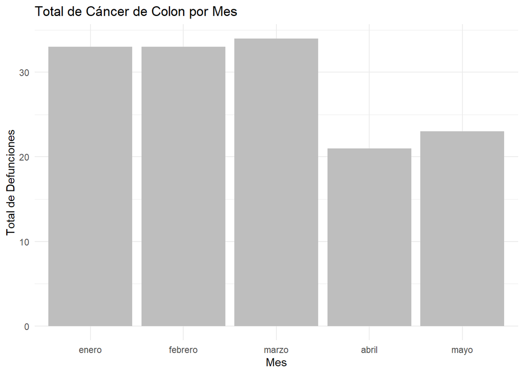

```r
library(ggplot2)
library(tidyr)


totalCC_Asturias <- tabla_resultadosCCAsturias[3, 3:7]
datos_long <- data.frame(mes = colnames(tabla_resultadosCCAsturias)[3:7],
                         valor = as.numeric(totalCC_Asturias))
datos_long$mes <- factor(datos_long$mes, levels = c("enero", "febrero", "marzo", "abril", "mayo"))
ggplot(datos_long, aes(x = mes, y = valor)) +
  geom_bar(stat = "identity", fill = "gray") +
  labs(title = "Total de Cáncer de Colon por Mes",
       x = "Mes",
       y = "Total de Defunciones") +
  theme_minimal()
```

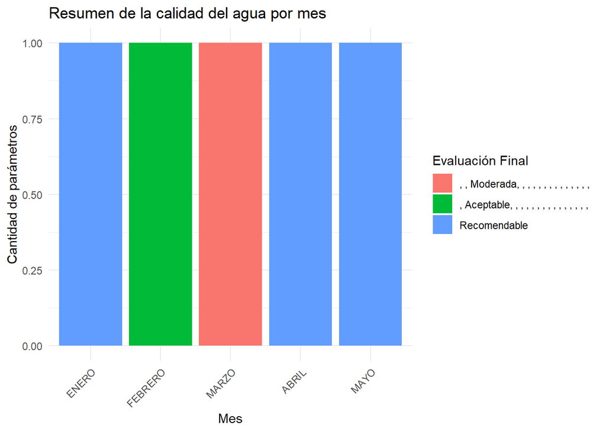

```r
#Ahora la de la calidad de la agua
ggplot(resumen_por_mes, aes(x = Mes, fill = Evaluación_final)) +
  geom_bar(position = "dodge") +
  labs(
    title = "Resumen de la calidad del agua por mes",
    x = "Mes",
    y = "Cantidad de parámetros",
    fill = "Evaluación Final"
  ) +
  theme_minimal() +
  theme(axis.text.x = element_text(angle = 45, hjust = 1))
```

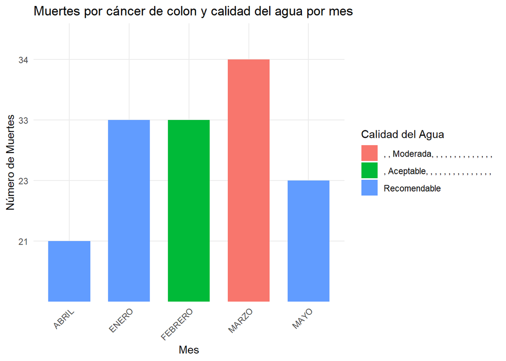

```r
totalCC_Asturias_columna <- totalCC_Asturias %>%
  pivot_longer(cols = everything(), names_to = "Mes", values_to = "Muertes")
totalCC_Asturias_columna <- totalCC_Asturias_columna %>%
  mutate(Mes = toupper(Mes))
resumen_por_mes <- resumen_por_mes %>%
  mutate(Evaluación_final = as.factor(Evaluación_final))
merged_data <- resumen_por_mes %>%
  left_join(totalCC_Asturias_columna, by = "Mes")
ggplot(merged_data, aes(x = Mes, y = Muertes, fill = Evaluación_final)) +
  geom_bar(stat = "identity", position = position_dodge(width = 0.9), width = 0.7) +
  labs(
    title = "Muertes por cáncer de colon y calidad del agua por mes",
    x = "Mes",
    y = "Número de Muertes",
    fill = "Calidad del Agua"
  ) +
  theme_minimal() +
  theme(
    axis.text.x = element_text(angle = 45, hjust = 1),
    legend.position = "right"  # Asegura que la leyenda aparezca a la derecha
  )
```